# Infant and under-five mortality in Minas Gerais, 2022 Census

This vignette estimates infant (1q0) and under-five (5q0) mortality in the state of Minas Gerais from the summary birth history of the 2022 Brazilian Census, using the Brass method (Hill 2013).

```r
library(childmortality)
```

## Choosing the model life table family

The indirect method relies on a model life table family, which sets the age pattern of mortality under age 5. To choose it, we compare pairs of 1q0 and 4q1 from Brazilian vital statistics with the patterns of the model families.

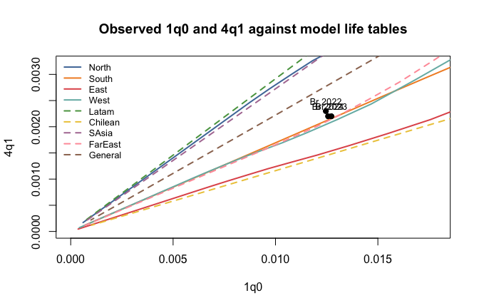

```r
# 1q0 and 4q1 from Brazilian vital statistics
obs <- list("Br 2022" = c(0.01246, 0.0023),
            "Br 2023" = c(0.01273, 0.0022),
            "Br 2024" = c(0.01257, 0.0022))
plot_mlt(obs)
```

Zooming in on the families closest to the observed points:

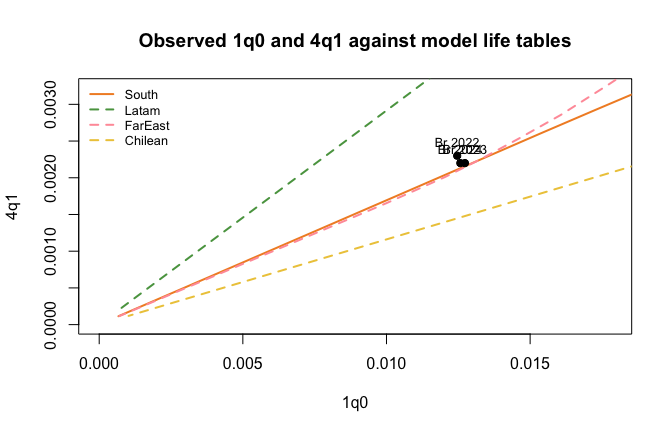

```r
plot_mlt(obs, families = c("South", "Latam", "FarEast", "Chilean"))
```

The South family (Princeton) is the most adequate for Brazil in 2022 and is used below.

## 0. Data: Minas Gerais

`MinasGerais` is a strand of the public-access microdata of the 2022 Census: women aged 15-49 living in the state, with the variables needed by the package (see `?MinasGerais`). Minas Gerais is often described as a synthesis of Brazil. Its regions range from the poorer, semi-arid north, close to the Brazilian Northeast, to the more developed south and Triângulo Mineiro, close to São Paulo, so the state’s averages are close to the national ones.

```r
data(MinasGerais)
mg <- MinasGerais
str(mg)
```

```
#> 'data.frame':    651761 obs. of  10 variables:
#>  $ P0180: int  7 5 6 6 9 6 10 8 4 4 ...
#>  $ P0150: int  2 2 2 2 2 2 2 2 2 2 ...
#>  $ P0110: num  1 1 2.18 2.35 4.49 ...
#>  $ P0320: int  0 0 0 0 0 0 1 0 0 0 ...
#>  $ P0330: int  3 0 1 1 0 1 1 2 0 0 ...
#>  $ P0340: int  3 0 1 1 0 1 2 2 0 0 ...
#>  $ P0350: int  0 NA 0 0 NA 0 1 0 NA NA ...
#>  $ P0360: int  3 NA 1 1 NA 1 1 2 NA NA ...
#>  $ P0370: int  3 NA 1 1 NA 1 2 2 NA NA ...
#>  $ P0400: int  2 NA 2 2 NA 2 2 2 NA NA ...
```

The variables keep the IBGE codes, so they are cleaned first:

- **age**: the public-access file gives only the five-year group (`P0180`, 4 = 15-19, …, 10 = 45-49). Any age inside the group works, because the method only uses these groups. Here we take the midpoint, `5 * P0180 - 3`.
- **children dead**: the census asks for children born alive (`P0340`) and children alive (`P0370`), so children dead are the difference. `P0370` is blank for women with no children, who have no dead children.
- **births in the last 12 months**: `P0400` is 1 = yes, 2 = no and blank for women with no children.

```r
mg$age <- 5 * mg$P0180 - 3
mg$cd <- ifelse(mg$P0340 == 0, 0, mg$P0340 - mg$P0370)
mg$births <- as.integer(mg$P0400 %in% 1)
```

Every function takes the weight (`P0110`) and, optionally, the sex filter. The file only has women, so the filter is shown for completeness.

```r
w <- "P0110"
female <- list(var = "P0150", female = 2)
```

## 1. Parity ratios

Average parity by age group of mother and the proportion of children dead:

```r
p <- avg_p(mg, "age", "P0340", weight = w, sex = female)
d <- dc(mg, "age", "P0340", "cd", weight = w, sex = female)
merge(p, d, by = c("i", "age_group", "x"))
```

```
#> Key: <i, age_group, x>
#>        i age_group     x     avg_p         dc
#>    <int>    <char> <num>     <num>      <num>
#> 1:     1     15-19     1 0.1026079 0.05935315
#> 2:     2     20-24     2 0.3959694 0.02709211
#> 3:     3     25-29     3 0.7971060 0.01896017
#> 4:     4     30-34     5 1.2189573 0.01893195
#> 5:     5     35-39    10 1.5665829 0.01810173
#> 6:     6     40-44    15 1.7914924 0.02186823
#> 7:     7     45-49    20 1.9349512 0.02601549
```

The parity ratios P(1)/P(2) and P(2)/P(3) enter the multipliers and the time reference of the estimates:

```r
c("P(1)/P(2)" = p$avg_p[1] / p$avg_p[2],
  "P(2)/P(3)" = p$avg_p[2] / p$avg_p[3])
```

```
#> P(1)/P(2) P(2)/P(3)
#> 0.2591308 0.4967588
```

## 2. Mean age at maternity

```r
m <- maam(mg, "age", "births", weight = w, sex = female)
m
```

```
#> [1] 28.50279
#> attr(,"asfr")
#>        i age_group        asfr
#>    <int>    <char>       <num>
#> 1:     1     15-19 0.029593444
#> 2:     2     20-24 0.064438456
#> 3:     3     25-29 0.072866575
#> 4:     4     30-34 0.066599179
#> 5:     5     35-39 0.044820046
#> 6:     6     40-44 0.015503978
#> 7:     7     45-49 0.002482634
```

The mean age at maternity is only used by the UN families (Brass-Palloni-Heligman variant). The South family is a Princeton family (Brass-Trussell variant, with `d(i) = 0`), so M does **not** enter the estimates below.

## 3. Infant (1q0) and under-five (5q0) mortality

The reference date of the 2022 Census is 1 August 2022.

```r
q1 <- est_mort_q(mg, y = 1, age = "age", ceb = "P0340", cd = "cd",
                 family = "South", ref_date = "20220801",
                 weight = w, sex = female)
q1
```

```
#>    age_group     i     avg_p         dc    mult_k     x        q_x     t_ref
#>       <char> <int>     <num>      <num>     <num> <num>      <num>     <num>
#> 1:     15-19     1 0.1026079 0.05935315 0.7360119     1 0.04368462  1.521128
#> 2:     20-24     2 0.3959694 0.02709211 0.9742114     2 0.02639345  2.848233
#> 3:     25-29     3 0.7971060 0.01896017 1.0106767     3 0.01916260  4.568768
#> 4:     30-34     4 1.2189573 0.01893195 1.0357816     5 0.01960936  6.510795
#> 5:     35-39     5 1.5665829 0.01810173 1.0596188    10 0.01918093  8.621900
#> 6:     40-44     6 1.7914924 0.02186823 1.0379626    15 0.02269840 11.020045
#> 7:     45-49     7 1.9349512 0.02601549 1.0222171    20 0.02659348 14.016073
#>    ref_date      alpha        q_y
#>       <num>      <num>      <num>
#> 1: 2021.060 -0.4037305 0.04368462
#> 2: 2019.733 -0.7768727 0.02119897
#> 3: 2018.012 -0.9872114 0.01402135
#> 4: 2016.070 -1.0125992 0.01333644
#> 5: 2013.959 -1.0562597 0.01223493
#> 6: 2011.561 -0.9913472 0.01390746
#> 7: 2008.565 -0.9400751 0.01538617
```

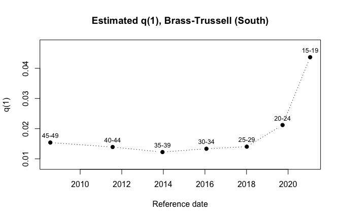

```r
plot(q1)
```

```r
q5 <- est_mort_q(mg, y = 5, age = "age", ceb = "P0340", cd = "cd",
                 family = "South", ref_date = "20220801",
                 weight = w, sex = female)
q5[, .(age_group, ref_date, q_y)]
```

```
#>    age_group ref_date        q_y
#>       <char>    <num>      <num>
#> 1:     15-19 2021.060 0.06331609
#> 2:     20-24 2019.733 0.03105371
#> 3:     25-29 2018.012 0.02060970
#> 4:     30-34 2016.070 0.01960936
#> 5:     35-39 2013.959 0.01799920
#> 6:     40-44 2011.561 0.02044340
#> 7:     45-49 2008.565 0.02260111
```

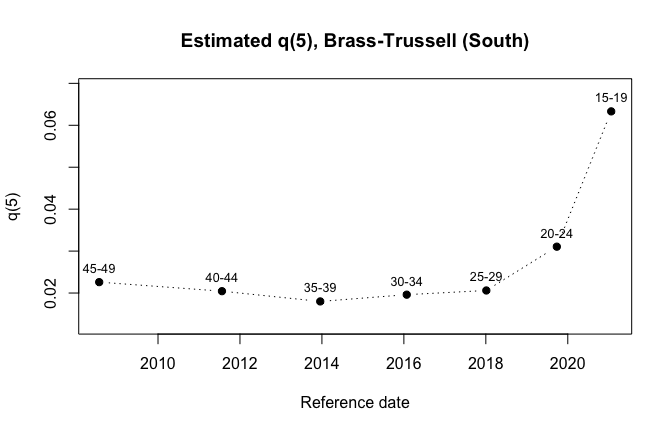

```r
plot(q5)
```

## Interpreting the estimates

Summary birth histories only show general, long-term trends, and even those require careful interpretation for recent years because of selection bias, particularly among younger women (ages 15-24): women who have children early are a selected group, and their children face higher mortality. The estimates from the older groups refer to a more distant past and are more affected by recall errors.

q(1) and q(5) are therefore better approximated by the value for the age group 25-29:

```r
best <- rbind(q1[age_group == "25-29", .(index = "1q0", q_y)],
              q5[age_group == "25-29", .(index = "5q0", q_y)])
best
```

```
#>     index        q_y
#>    <char>      <num>
#> 1:    1q0 0.01402135
#> 2:    5q0 0.02060970
```

For Minas Gerais, this gives an infant mortality of 14 and an under-five mortality of 20.6 deaths per 1,000 live births.

## References

Hill K (2013). Indirect estimation of child mortality. In Moultrie TA et al. (eds), *Tools for Demographic Estimation*. Paris: IUSSP. https://demographicestimation.iussp.org/content/indirect-estimation-child-mortality

IBGE. Censo Demográfico 2022, microdados (acesso público). https://www.ibge.gov.br/estatisticas/sociais/trabalho/22827-censo-demografico-2022.html?=&t=microdados